# Practice Activity 9.1

Author

Samuel Lonac

```python
import pandas as pd
import numpy as np
from sklearn.pipeline import Pipeline
from sklearn.neighbors import KNeighborsClassifier
from sklearn.tree import DecisionTreeClassifier
from sklearn.linear_model import LogisticRegression
from sklearn.preprocessing import StandardScaler
from sklearn.compose import make_column_selector, ColumnTransformer
from sklearn.discriminant_analysis import LinearDiscriminantAnalysis
from sklearn.svm import SVC
from sklearn.model_selection import GridSearchCV
from plotnine import ggplot, aes, geom_point, geom_abline, annotate
```

```python
hd = pd.read_csv("https://www.dropbox.com/scl/fi/0vrpdnq5asmeulc4gd50y/ha_1.csv?rlkey=ciisalceotl77ffqhqe3kujzv&dl=1")
```

```python
hd.head()
```

|  | Name | age | sex | cp | trtbps | chol | restecg | thalach | diagnosis |
| --- | --- | --- | --- | --- | --- | --- | --- | --- | --- |
| 0 | Magnolia Cassin | 60 | 1 | 1 | 117 | 230 | 1 | 160 | No Disease |
| 1 | Dr. Cathern Heathcote | 60 | 0 | 3 | 102 | 318 | 1 | 160 | Disease |
| 2 | Miles Wolf | 62 | 0 | 3 | 130 | 263 | 1 | 97 | No Disease |
| 3 | Mikaila Block | 43 | 1 | 1 | 115 | 303 | 1 | 181 | Disease |
| 4 | Mrs. Jacquline Marquardt | 66 | 1 | 1 | 120 | 302 | 0 | 151 | Disease |

```python
hd.describe()
```

|  | age | sex | cp | trtbps | chol | restecg | thalach |
| --- | --- | --- | --- | --- | --- | --- | --- |
| count | 204.000000 | 204.000000 | 204.000000 | 204.000000 | 204.000000 | 204.000000 | 204.000000 |
| mean | 53.813725 | 0.666667 | 2.049020 | 131.245098 | 248.377451 | 0.558824 | 149.147059 |
| std | 9.354781 | 0.472564 | 1.030352 | 18.352024 | 53.176624 | 0.526603 | 23.990925 |
| min | 29.000000 | 0.000000 | 1.000000 | 94.000000 | 126.000000 | 0.000000 | 71.000000 |
| 25% | 46.000000 | 0.000000 | 1.000000 | 120.000000 | 212.750000 | 0.000000 | 132.000000 |
| 50% | 54.000000 | 1.000000 | 2.000000 | 129.500000 | 241.000000 | 1.000000 | 153.500000 |
| 75% | 61.000000 | 1.000000 | 3.000000 | 140.000000 | 276.250000 | 1.000000 | 166.250000 |
| max | 77.000000 | 1.000000 | 4.000000 | 200.000000 | 564.000000 | 2.000000 | 202.000000 |

```python
hd.info()
```

```
<class 'pandas.core.frame.DataFrame'>
RangeIndex: 204 entries, 0 to 203
Data columns (total 9 columns):
 #   Column     Non-Null Count  Dtype
---  ------     --------------  -----
 0   Name       204 non-null    object
 1   age        204 non-null    int64
 2   sex        204 non-null    int64
 3   cp         204 non-null    int64
 4   trtbps     204 non-null    int64
 5   chol       204 non-null    int64
 6   restecg    204 non-null    int64
 7   thalach    204 non-null    int64
 8   diagnosis  204 non-null    object
dtypes: int64(7), object(2)
memory usage: 14.5+ KB
```

## The Data

At this link, you will find a dataset containing information about heart disease patients: https://www.dropbox.com/scl/fi/0vrpdnq5asmeulc4gd50y/ha_1.csv?rlkey=ciisalceotl77ffqhqe3kujzv&dl=1

A description of the original dataset can be found here: https://archive.ics.uci.edu/dataset/45/heart+disease (However, this dataset has been cleaned and reduced, and the people have been given fictious names.)

## 1. Logistic Regression

Fit a Logistic Regression using only `age` and `chol` (cholesterol) as predictors.

For a 55 year old, how high would their cholesterol need to be for the doctors to predict heart disease is present?

How high for the doctors to estimate a 90% chance that heart disease is present?

```python
X = hd[['age','chol']]
y = hd['diagnosis']


log_pipeline = Pipeline([
    ('classifier', LogisticRegression())
])
```

```python
fitted_pipeline = log_pipeline.fit(X, y)

coefs_log_reg = fitted_pipeline.named_steps['classifier'].coef_[0]
intercept_log_reg = fitted_pipeline.named_steps['classifier'].intercept_[0]
```

```python
coefs_log_reg
```

```
array([0.04686331, 0.00180124])
```

```python
intercept_log_reg
```

```
-3.2401122588583937
```

```python
age = 55
age_coef_log_reg = coefs_log_reg[0]
chol_coef_log_reg = coefs_log_reg[1]

#50% probability
chol_50_percent_log_reg = (-intercept_log_reg - (age_coef_log_reg * age)) / chol_coef_log_reg

#90% probability
log_odds_90_percent = np.log(0.9/(1 - 0.9))
chol_90_percent_log_reg = (log_odds_90_percent - intercept_log_reg - (age_coef_log_reg * age)) / chol_coef_log_reg

chol_50_percent_log_reg, chol_90_percent_log_reg
```

```
(367.8748897986711, 1587.7158792750995)
```

## 2. Linear Discriminant Analysis

Fit an LDA model using only `age` and `chol` (cholesterol) as predictors.

For a 55 year old, how high would their cholesterol need to be for the doctors to predict heart disease is present?

```python
lda_pipeline = Pipeline([
    ('classifier', LinearDiscriminantAnalysis())
])

fitted_pipeline = lda_pipeline.fit(X, y)

coefs_lda = fitted_pipeline.named_steps['classifier'].coef_[0]
intercept_lda = fitted_pipeline.named_steps['classifier'].intercept_[0]
```

```python
coefs_lda
```

```
array([0.04655744, 0.00178967])
```

```python
intercept_lda
```

```
-3.2196776604068784
```

```python
age = 55
age_coef_lda = coefs_lda[0]
chol_coef_lda = coefs_lda[1]

#50 percent prob
chol_50_percent_lda = (-intercept_lda - (age_coef_lda * age)) / chol_coef_lda

chol_50_percent_lda
```

```
368.235357529938
```

## 3. Support Vector Classifier

Fit an SVC model using only `age` and `chol` as predictors. Don’t forget to tune the regularization parameter.

For a 55 year old, how high would their cholesterol need to be for the doctors to predict heart disease is present?

```python
svc_pipeline = Pipeline([
    ('classifier', SVC(kernel='linear'))
])

tuner = {
    "classifier__C": np.array([0.25, 0.5, 0.75, 1])
}

grid_svc_pipeline = GridSearchCV(svc_pipeline, tuner, cv=5, scoring="accuracy")

fitted_pipeline = grid_svc_pipeline.fit(X, y)

coefs_svc = fitted_pipeline.best_estimator_.named_steps['classifier'].coef_[0]
intercept_svc = fitted_pipeline.best_estimator_.named_steps['classifier'].intercept_[0]
```

```python
coefs_svc
```

```
array([0.06439324, 0.0036604 ])
```

```python
intercept_svc
```

```
-4.686225836274493
```

```python
age = 55
age_coef_svc = coefs_svc[0]
chol_coef_svc = coefs_svc[1]
chol_50_percent_svc = (-intercept_svc - (age_coef_svc * age)) / chol_coef_svc

chol_50_percent_svc
```

```
312.69728442857627
```

## 4. Comparing Decision Boundaries

Make a scatterplot of `age` and `chol`, coloring the points by their true disease outcome. Add a line to the plot representing the **linear separator** (aka **decision boundary**) for each of the three models above.

```python
log_reg_line = geom_abline(intercept= -intercept_log_reg/chol_coef_log_reg, slope=-age_coef_log_reg/chol_coef_log_reg, linetype= 'dashed' , color='red')
lda_line = geom_abline(intercept= -intercept_lda/chol_coef_lda, slope=-age_coef_lda/chol_coef_lda, linetype='dashed', color= 'blue')
svc_line = geom_abline(intercept= -intercept_svc/chol_coef_svc, slope=-age_coef_svc/chol_coef_svc, linetype='dashed', color='green')
```

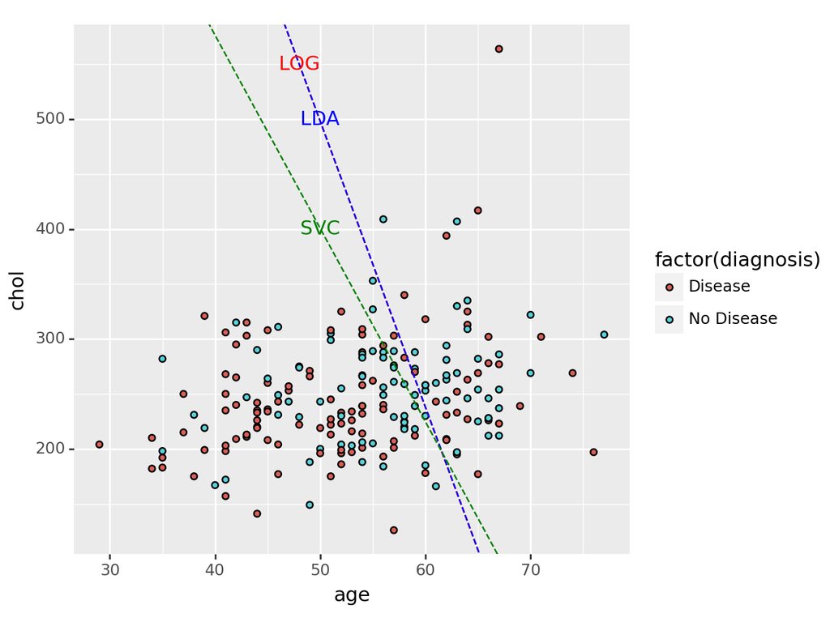

```
<Figure Size: (640 x 480)>
```

```python
(ggplot(hd,
  aes(x = 'age',
      y = 'chol',
      fill = 'factor(diagnosis)'
     ))
+ geom_point()
+ log_reg_line
+ lda_line
+ svc_line
+ annotate("text", x = 48, y = 550, label = "LOG", color='red')
+ annotate ("text", x = 50, y = 500, label = "LDA", color= 'blue')
+ annotate ("text", x = 50, y = 400, label = "SVC", color='green')
)
```